# USF Marketing Site Web Traffic Analysis

This project explores a dataset of 795 rows x 10 columns. Each column is a webpage on University of San Francisco’s Marketing Site. The 10 highest activity pages were chosen to avoid sparsity. Each row contains the daily count of pageviews for that each of these 10 webpages. The complete data set represents about 26 months of activity.

In order of activity, the pages studied in this project are:

1. [USF’s Homepage](http://www.usfca.edu/)
2. [Arts & Sciences Undergrad Programs](http://www.usfca.edu/arts-sciences/undergraduate-programs)
3. [Undergrad Computer Science](http://www.usfca.edu/arts-sciences/undergraduate-programs/computer-science)
4. [Undergrad Biology](http://www.usfca.edu/arts-sciences/undergraduate-programs/biology)
5. [Arts & Sciences Homepage](http://www.usfca.edu/arts-sciences)
6. [Design Major](http://www.usfca.edu/arts-sciences/undergraduate-programs/art-architecture/design)
7. [Undergrad Data Science](http://www.usfca.edu/arts-sciences/undergraduate-programs/data-science) (represent!)
8. [Media Studies](http://www.usfca.edu/arts-sciences/undergraduate-programs/media-studies)
9. [Communication Studies](http://www.usfca.edu/arts-sciences/undergraduate-programs/communication-studies)
10. [Dual Degree Teacher Prep](http://www.usfca.edu/arts-sciences/undergraduate-programs/dual-degree-teacher-preparation)

I have one main question: **Can we predict tomorrows pageviews with higher accuracy if we know the activity of other pages?**

This project has several parts:

1. Fetch data updates using Google drive API
2. Read and Write from a database
3. Automated analysis of several time series models: ARMA, VARMA, VARIMA, SARIMA
4. Run this software on a Raspberry Pi

The “automated analysis” here is a proof of concept instead of a useful product. This code could be adapted to provide close to real-time reporting or more practical model fitting.

#### 1. Connect to Google Drive

```r
data.folder.id <- "1CakyziIpT39meYk05QaBNNEQf4aoWtXh"

#if you don't have permission, stop the script
tryCatch({
  data.folder <- drive_get(as_id(data.folder.id))
},error=function(e){
  print(e)
  drive_deauth()
  stop()
})

file.tibble <- drive_ls(data.folder)


for (key in file.tibble$id){
  tryCatch({
    setwd("./data")
    drive_download(as_id(key)) #download files to localhost
  },error=function(e){
    #do nothing
  })
}

#read files from localhost

data <- read.csv(file.tibble[1,"name"] %>% as.character())
if (nrow(file.tibble) > 1){
  for (filename in file.tibble[2:nrow(file.tibble),"name"] %>% unlist()) {
    data <- rbind(data,read.csv(filename)) #concatenate files
  }
}
names(data) <- c("Page","Date","Pageviews","Unique Pageviews","Avg Time on Page","Entrances","Bounce Rate","Percent Exit","Page Value")
data <- as.data.frame(data)
```

#### 2. Import data to database

```r
database <- dbConnect(MySQL(), user='root', password='MyNewPass', dbname='senior_project', host='localhost')

dbWriteTable(database,name="webtraf",data,append=TRUE,row.names=FALSE)
```

```
## [1] TRUE
```

# Analysis

## ARMA

To select the ideal parameters for the ARMA model, I fit models on a lag of anywhere between 1 and 14 days for both parameters. The prediction error of each of these models produced a heatmap. I focus on just 4 pages to compare ARMA and VARMA.

From left to right, top to bottom:

| Page | Content |
| --- | --- |
| Page 1 | Undergrad Data Science |
| Page 3 | Undergrad Computer Science |
| Page 7 | Communication Studies |
| Page 10 | USF’s Homepage |

The heatmaps look generally the same, with higher sparsity seemingly related to a higher chance of a failed model fit.

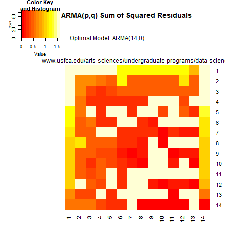

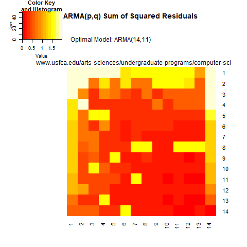

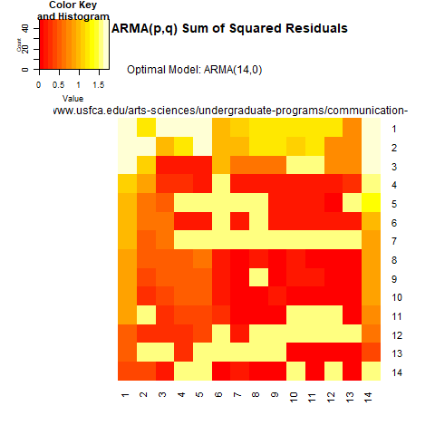

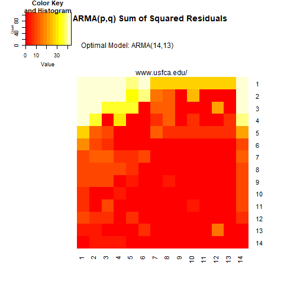

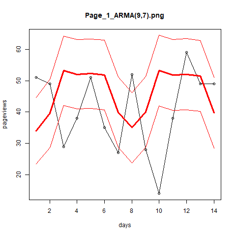

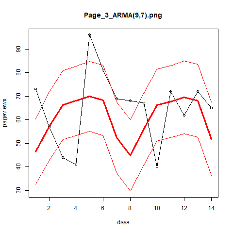

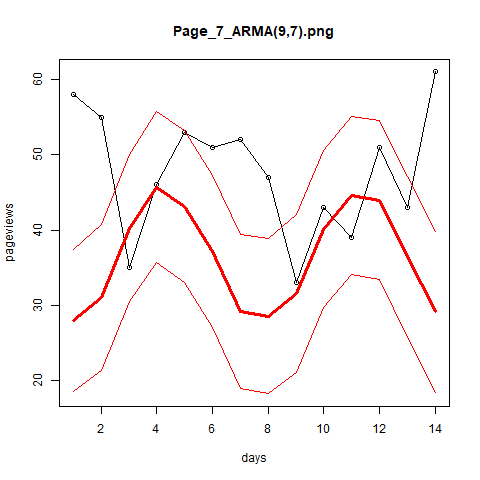

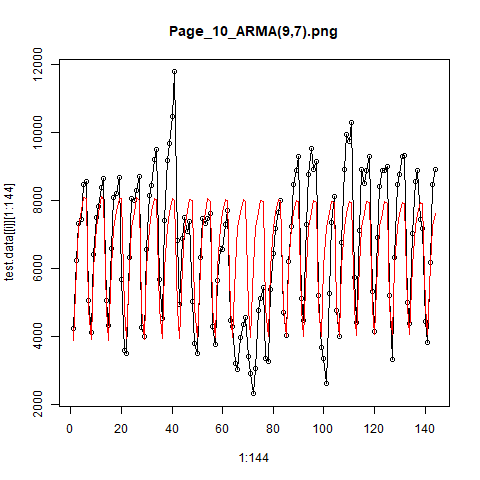

## VARMA

The VARMA model has many more parameters than ARMA. Accordingly, it requires many more degrees of freedom to fit. I fit a the smallest choice VARMA(p=1,q=1) to the data.

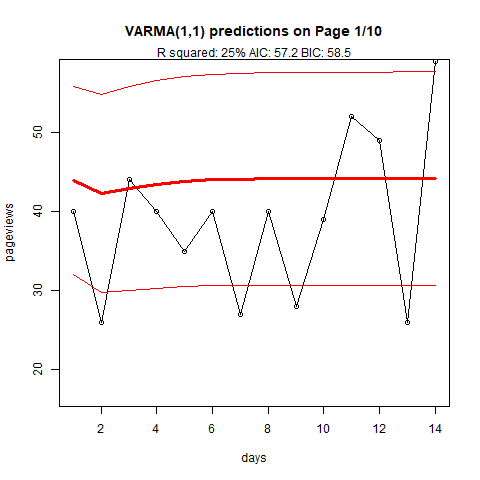

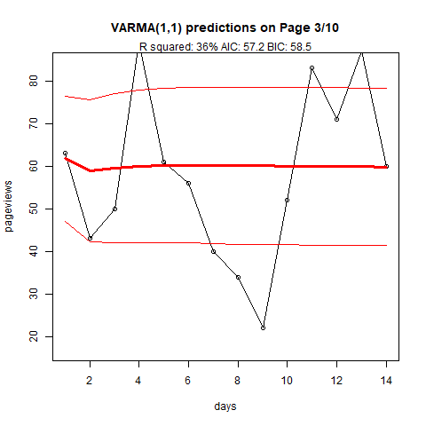

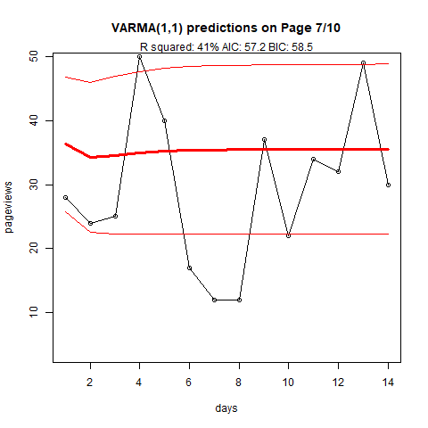

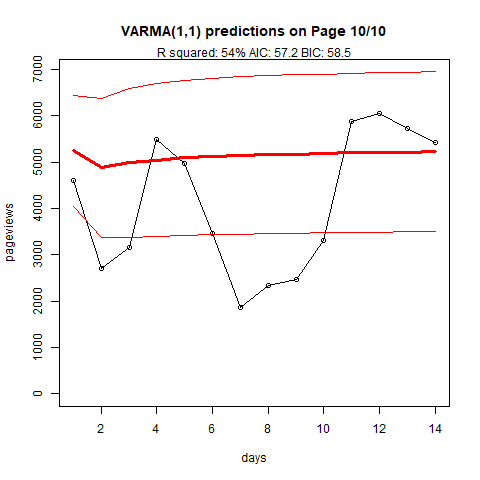

## Comparing ARMA and VARMA

```
##  [1]  TRUE  TRUE  TRUE  TRUE  TRUE  TRUE  TRUE FALSE  TRUE FALSE
```

## ARIMA

Below are ARIMA predictions for www.usfca.edu/

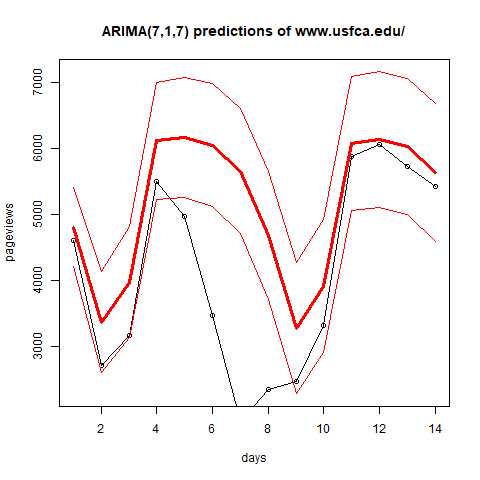

## SARIMA

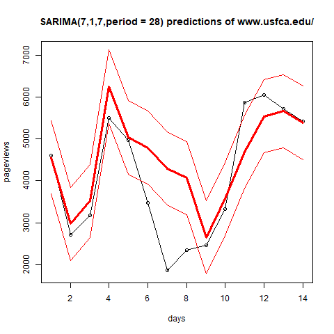

## Comparing ARIMA and SARIMA

The 28-day period SARIMA performs significantly better than ARIMA.

[figure not shown]